# Template using manual toggle between questions & solutions

Clement Lee

2021-03-17

# Instructions

If you are not familiar with the syntax of R and/or Markdown, simply:

1. open the source code, which has the file extension “Rmd”, in RStudio;
2. click the black triangle next to the *Knit* button;
3. click the *Knit to <required file format>* button, and the generated document will pop up;
4. toggle between `include = FALSE` & `include = TRUE` below, which correspond to the questions (only) and the solutions, respectively, and see the differences in the generated documents;
5. try changing the questions & solutions below & observe the difference in the generated document;
6. read the content of the questions & solutions in this file (no matter it is the source code or generated document) for more information.

In the source code, a code chunk starts with a line of triple backticks & the curly bracket pair, and ends with a line of triple backticks. Everything in-between will be evalulated by `R`.

# Question 1

Solution:

# Question 2

(This is not really a question but an explanation - see above.) You type the “normal” text, usually the question, in a line without any “environment” i.e. there are no backticks, quotes, or hashtags etc. before or after the line. If you want `R` to evaluate something inline, type

1. a single backtick, then
2. the character “r” followed by a space, then
3. the expression in `R` you want to evaulate, and finally
4. another single backtick.

See how it is done in the source code: $1+2=$ 3. You will also see that maths being typeset between a pair of single dollar signs are allowed.

Solution:

You should only see this line in the generated solutions, pdf or html, but not in the generated questions. This is because we harness the power of the inline evaluation using a pair of backticks, and the object $\texttt{is\_answer}$ we have defined in the source code. This is why the text typed after $\texttt{`r if (is\_answer) \{"}$ and before $\texttt{"\}`}$ in the source code will only be visible in the solution.

# Question 3

This is a “pure” maths question, with no statistical or data analysis in `R` required. Prove that
$$(a+b)^2=a^2+2ab+b^2.$$
(In the source code you will also see that maths typeset between a pair of double dollar signs are allowed. Other LaTeX environments allowed are `align`, `equation`, `eqnarray`, their no-numbering versions i.e. with asterisks, and `\[ \]`.)

Solution:

The solution is
$$\begin{align*}
(a+b)^2 &= (a+b)(a+b)\\
&= a^2+ab+ba+b^2\\
&= a^2+2ab+b^2
\end{align*}$$
You can see that maths environments also work within the solution. However, any backslash in LaTeX has to be doubled because there is an additional layer of evaluated. The solution content is evaluated by $\texttt{R}$ first before being rendered by Markdown. This also applies to other symbols and commands e.g. $\alpha$ and $\boldsymbol{1}$ (see source code).

# Question 4

This is a data analysis question. Plot the `cars` data set that is available in `R`.

Solution:

As previous questions, we can type here any solution text unrelated to data analysis in $\texttt{R}$. For the data analysis, both the $\texttt{R}$ code and the output (which is a plot here) can done within the code chunk i.e. anything sandwiched by two lines of triple backticks, the first one which also has $\texttt{\{r\}}$. The cars data set is

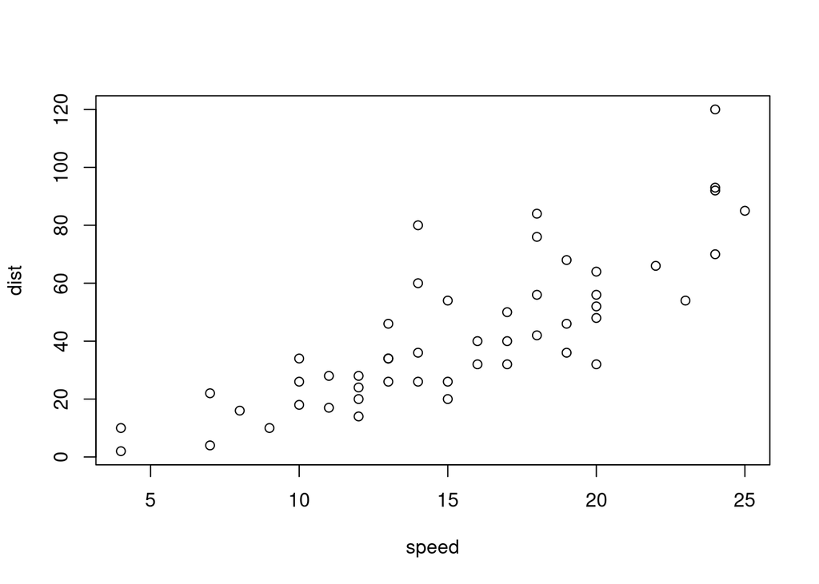

```r
plot(cars)
```

Remember the plot (or in fact other kinds of output) doesn’t need to be evalulated and saved manually prior to the generation of the pdf or html, as long as they are proper $\texttt{R}$ commands.

# Question 5

What if I want to evaluate something in `R` but not print the output? Or what if I want to show the code but not evaluate it? More generally, what if I want to customise the printing of some/all of the `R` code, numerical output, and graphical output?

Solution:

All evaluations and output printing of $\texttt{R}$ code chunks can be customised. A whole list of options can be found at https://yihui.org/knitr/options/.

# Question 6

What do I need to be aware of when modifying this template?